# Quantum Computing and Qiskit

AMCEC, Department Of Physics

Suhas P K

2023-07-18

$$\newcommand{\ket}[1]{\left|{#1}\right\rangle}$$
$$\newcommand{\bra}[1]{\left\langle{#1}\right|}$$
$$\newcommand{\braket}[2]{\left\langle{#1}\middle|{#2}\right\rangle}$$

### Representation of Qubits

The **pure state space qubits**(Two level quantum mechanical systems) can be visualised using an imaginary sphere called **BLOCH SPHERE**. It has a unit radius.

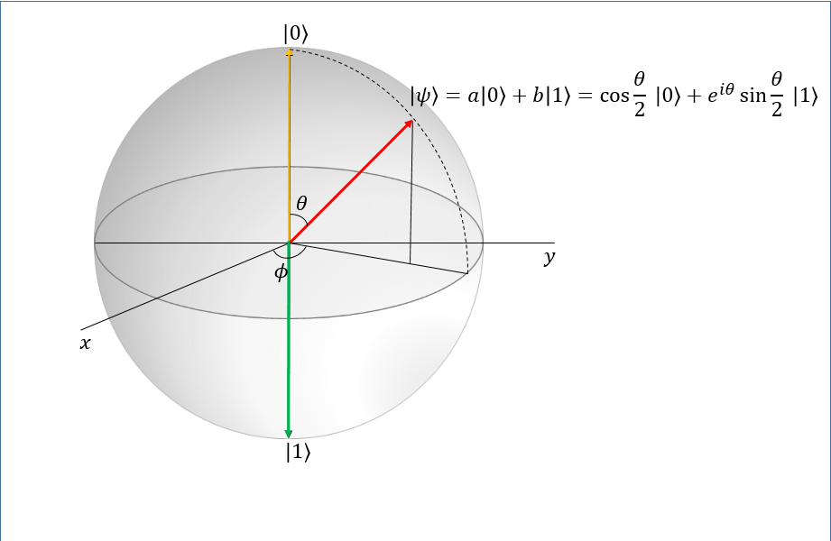

The arrow on the sphere represents the state of the Qubit. The north and south spoles are used to represent the basis states $\ket{0}$ and $\ket{1}$ respectively. The other locations are the superpositions of $\ket{0}$ and $\ket{1}$ represented by $\ket{\psi} = a\ket{0} +b\ket{1}$ where $a$ and $b$ are complex numbers and satisfy the condition $a^{*}a + b^{*}b = |a|^2 + |b|^2 = 1$ signifies the probability. Thus, a qubit can be any point on the bloch sphere.

```r
library(reticulate)
```

[output not shown]

[figure not shown]

```python
from qiskit import *
from qiskit.visualization import plot_bloch_multivector, visualize_transition
from qiskit_textbook.tools import array_to_latex
```

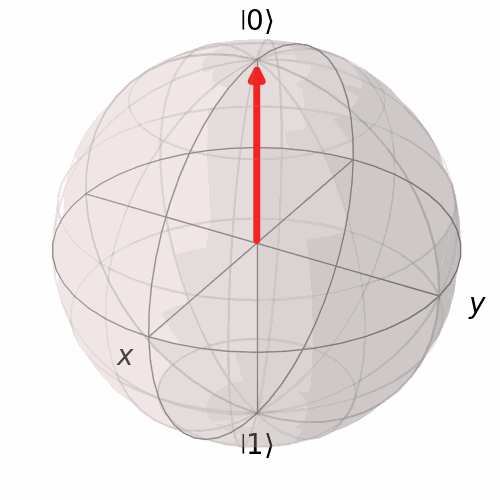

```python
visualize_transition(qc,trace = True, saveas = "xgate.gif", fpg = 100, spg = 2)
```